# Task_1_Iris_Exploration

Objective: Learn how to load, inspect, and visualize a dataset to understand data trends and distributions.

Import Important Libraries

```python
import pandas as pd
import seaborn as sns
import matplotlib.pyplot as plt
import warnings

warnings.filterwarnings('ignore') # Keeps the output clean
%matplotlib inline
```

Loading Dataset

```python
# Load the iris dataset from seaborn's built-in library
df = sns.load_dataset('iris')
print("Dataset loaded successfully!")
```

```
Dataset loaded successfully!
```

Exploratory Data Analysis (EDA) of the Iris Dataset

Data Inspection

```python
# Displaying dimensions and column names
print(f"Dataset Shape: {df.shape}")
print("-" * 30)
print(f"Columns: {list(df.columns)}")
print("-" * 30)
df.head()
```

```
Dataset Shape: (150, 5)
------------------------------
Columns: ['sepal_length', 'sepal_width', 'petal_length', 'petal_width', 'species']
------------------------------
```

|  | sepal_length | sepal_width | petal_length | petal_width | species |
| --- | --- | --- | --- | --- | --- |
| 0 | 5.1 | 3.5 | 1.4 | 0.2 | setosa |
| 1 | 4.9 | 3.0 | 1.4 | 0.2 | setosa |
| 2 | 4.7 | 3.2 | 1.3 | 0.2 | setosa |
| 3 | 4.6 | 3.1 | 1.5 | 0.2 | setosa |
| 4 | 5.0 | 3.6 | 1.4 | 0.2 | setosa |

"The dataset contains 150 rows and 5 columns (4 features and 1 target variable)."

```python
# Checking for data types and null values
df.info()
```

```
<class 'pandas.core.frame.DataFrame'>
RangeIndex: 150 entries, 0 to 149
Data columns (total 5 columns):
 #   Column        Non-Null Count  Dtype
---  ------        --------------  -----
 0   sepal_length  150 non-null    float64
 1   sepal_width   150 non-null    float64
 2   petal_length  150 non-null    float64
 3   petal_width   150 non-null    float64
 4   species       150 non-null    object
dtypes: float64(4), object(1)
memory usage: 6.0+ KB
```

"Initial inspection via .info() confirms there are no missing values, meaning the data is clean and ready for visualization."

```python
# Statistical overview
df.describe()
```

|  | sepal_length | sepal_width | petal_length | petal_width |
| --- | --- | --- | --- | --- |
| count | 150.000000 | 150.000000 | 150.000000 | 150.000000 |
| mean | 5.843333 | 3.057333 | 3.758000 | 1.199333 |
| std | 0.828066 | 0.435866 | 1.765298 | 0.762238 |
| min | 4.300000 | 2.000000 | 1.000000 | 0.100000 |
| 25% | 5.100000 | 2.800000 | 1.600000 | 0.300000 |
| 50% | 5.800000 | 3.000000 | 4.350000 | 1.300000 |
| 75% | 6.400000 | 3.300000 | 5.100000 | 1.800000 |
| max | 7.900000 | 4.400000 | 6.900000 | 2.500000 |

"Based on .describe(), we can see that the 'petal_length' has a high standard deviation, suggesting significant variation between the different iris species."

Visualizing Relationships

Scatter Plot

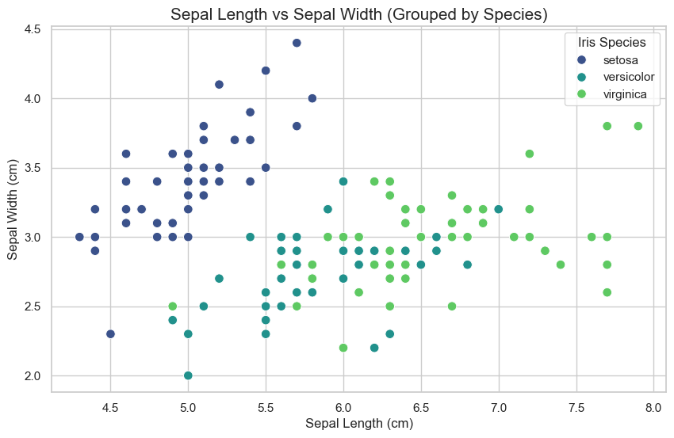

```python
# Setting the aesthetic style of the plots
sns.set_theme(style="whitegrid")

plt.figure(figsize=(10, 6))
sns.scatterplot(data=df, x='sepal_length', y='sepal_width', hue='species', palette='viridis', s=70)

plt.title('Sepal Length vs Sepal Width (Grouped by Species)', fontsize=15)
plt.xlabel('Sepal Length (cm)')
plt.ylabel('Sepal Width (cm)')
plt.legend(title='Iris Species')
plt.show()
```

Observation: The scatter plot reveals a clear cluster for the Setosa species (purple/darker dots), showing it has smaller sepal length but larger sepal width compared to the others. Versicolor and Virginica have some overlap, suggesting they are more closely related in sepal dimensions.

Histograms

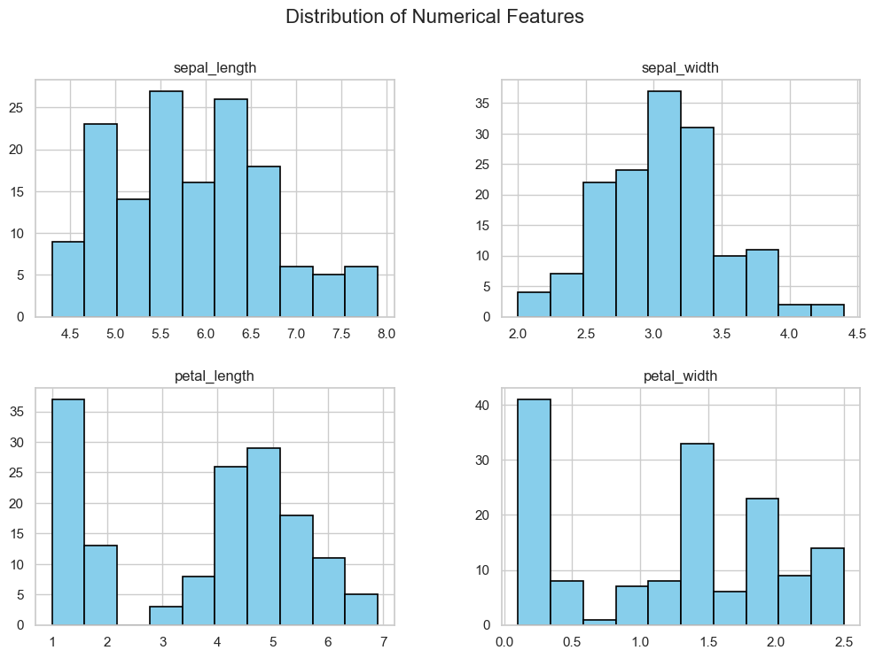

```python
# Plotting histograms for all numerical features
df.hist(edgecolor='black', linewidth=1.2, figsize=(12, 8), color='skyblue')
plt.suptitle('Distribution of Numerical Features', fontsize=16)
plt.show()
```

Box Plots

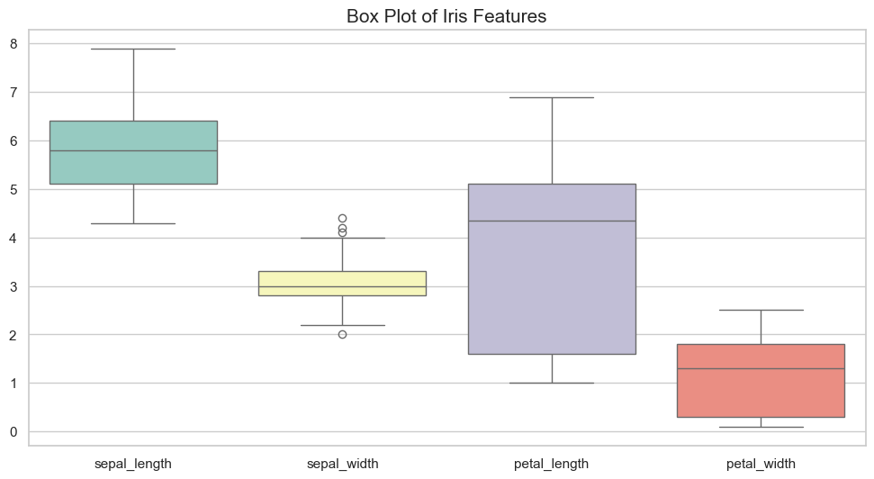

```python
plt.figure(figsize=(12, 6))
sns.boxplot(data=df, palette="Set3")
plt.title('Box Plot of Iris Features', fontsize=15)
plt.show()
```

```python
# Calculating correlation only for numeric columns
correlation_matrix = df.corr(numeric_only=True)
correlation_matrix
```

|  | sepal_length | sepal_width | petal_length | petal_width |
| --- | --- | --- | --- | --- |
| sepal_length | 1.000000 | -0.117570 | 0.871754 | 0.817941 |
| sepal_width | -0.117570 | 1.000000 | -0.428440 | -0.366126 |
| petal_length | 0.871754 | -0.428440 | 1.000000 | 0.962865 |
| petal_width | 0.817941 | -0.366126 | 0.962865 | 1.000000 |

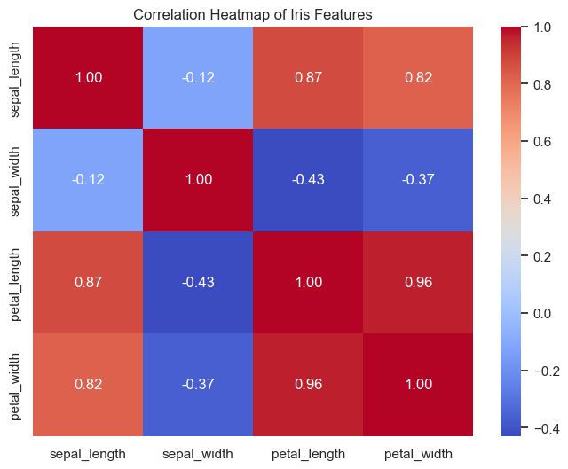

```python
plt.figure(figsize=(8, 6))
sns.heatmap(correlation_matrix, annot=True, cmap='coolwarm', fmt=".2f")
plt.title('Correlation Heatmap of Iris Features')
plt.show()
```